# Tugas Praktikum 4

2025-09-18

## White Noise

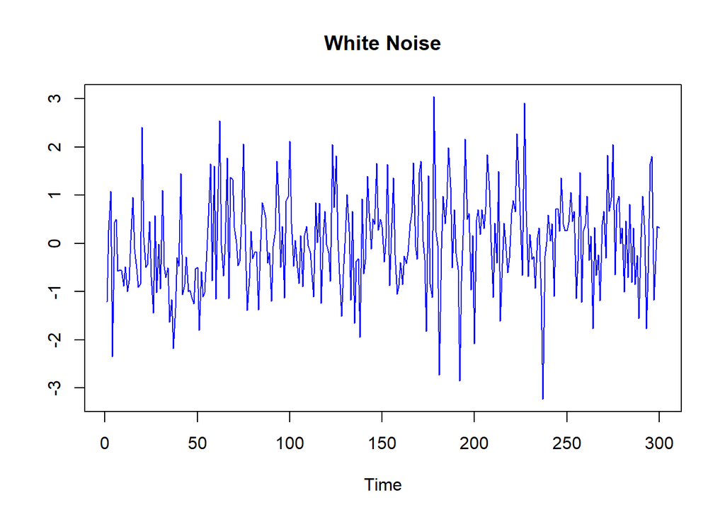

```r
set.seed(1234)
w = rnorm(300)
ts.plot(w, main="White Noise", ylab="", col="blue")
```

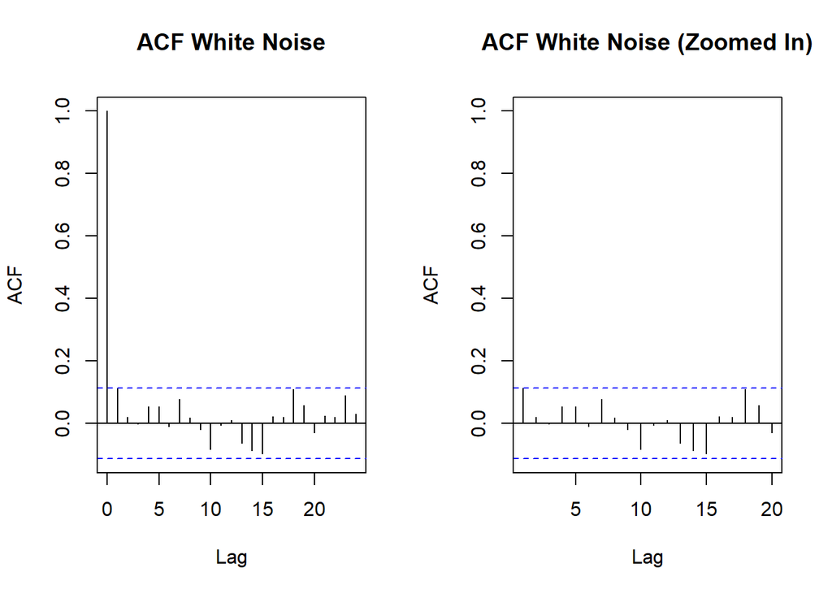

```r
par(mfrow=c(1,2))
acf(w, main="ACF White Noise")
acf(w, xlim=c(1,20), main="ACF White Noise (Zoomed In)")
```

# 1. Model MA ## Proses MA Proses MA dapat dituliskan sebagai berikut:

$$y_{t} = c + e_t + \theta_{1}e_{t-1} + \theta_{2}e_{t-2} + \dots +
\theta_{q}e_{t-q} = c+{e_t+\sum_{i=1}^p \theta_ie_{t-i}}$$
### Pembangkitan MA(2) Akan dicoba membangkitkan proses MA, yaitu MA(2) dengan $\theta1 = 0.4$ dan $\theta2 = 0.6$ sebanyak 300 observasi dan $c=0$. Karena diperlukan satu nilai awal untuk $e_{t-1}$, masukkan nilai pertama white noise sebagai nilai awal tersebut.

```r
set.seed(1234)
```

MA(2):
$$y_t = e_t+0.4e_{t-1}+0.6e_{t-2}$$
### MA Manual

```r
n = 300
wn = rnorm(n)

ma2 = rep(NA, n)

ma2[1] = wn[1]
ma2[2] = wn[2] + 0.4*wn[1]

for(i in 3:n){
  ma2[i] = wn[i] + 0.4*wn[i-1] + 0.6*wn[i-2]
}

ma2
```

```
##   [1] -1.207065749 -0.205397058  0.471173424 -1.745463687  0.141510314
##   [6] -0.729712854 -0.114842790 -0.472894305 -1.127948717 -1.443797742
##  [11] -1.171879031 -1.723286222 -1.461924092 -0.845074607  0.519525249
##  [16]  0.312187420  0.020572732 -1.181770516 -1.508255550  1.534249256
##  [21]  0.598119283  1.012450498 -0.556369299 -0.011041246 -0.774213194
##  [26] -1.449939345 -0.420758391 -1.662676381 -0.079747157 -1.556197355
##  [31]  0.718835126 -0.596243221 -0.238298741 -1.070389923 -2.255260716
##  [36] -2.120011486 -3.624543435 -2.913580609 -2.138714925 -1.388210999
##  [41]  1.086560934 -0.768382742 -0.413123964 -1.263954490 -1.619808057
##  [46] -1.534624150 -2.091327966 -2.276021753 -1.689013389 -1.457572736
##  [51] -2.319068111 -1.602598402 -2.425338748 -1.807763414 -1.233628102
##  [56] -0.110845196  1.775654086  0.223607057  2.285258743 -0.979456751
##  [61]  1.157010823  2.116941328  1.378789117  0.845856907 -0.296314421
##  [66]  1.372262398 -0.432336811  1.978634754  1.193531021  1.688995021
##  [71]  0.939220832 -0.250827924 -0.544575725  0.228395751  2.109671129
```

[output cut: 45 more lines]

Selain menggunakan cara di atas, pembangkitan proses MA(2) dapat dilakukan dengan fungsi `arima.sim()` sebagai berikut.

### Arima.Sim

```r
ma22 <- arima.sim(
  model = list(order = c(0,0,2), ma = c(0.4, 0.6)),
  n = 300
)

ma22
```

```
## Time Series:
## Start = 1
## End = 300
## Frequency = 1
##   [1] -0.908714261  0.366069559  0.319892749 -0.033692645 -0.749809541
##   [6]  1.023224875 -0.103827746  1.553027734  1.508813504  1.490258435
##  [11]  0.638775303  0.057508568 -0.761313741  1.006804154  0.046165301
##  [16]  2.226792228 -0.031351321  0.058227766 -0.452682262 -0.306828839
##  [21] -0.408896770 -1.768664231 -0.905163217 -1.653388217  0.814020129
##  [26] -0.949587092  1.394975120 -0.770061199  0.708742509  0.626264945
##  [31]  0.016220780  0.886163244 -0.177443664 -0.837739266 -0.776948985
##  [36]  0.830630275  0.271737011  0.068438994 -0.509614613 -0.182137038
##  [41]  1.054967504  1.724174690  1.131301118  1.891160132 -0.238116411
##  [46] -1.951472236 -1.868044756 -2.111236903 -2.805388403 -0.673455997
##  [51] -1.948408128 -0.202080988 -2.147789666 -0.222949385  1.157974906
```

[output cut: 49 more lines]

### Plot MA(2)

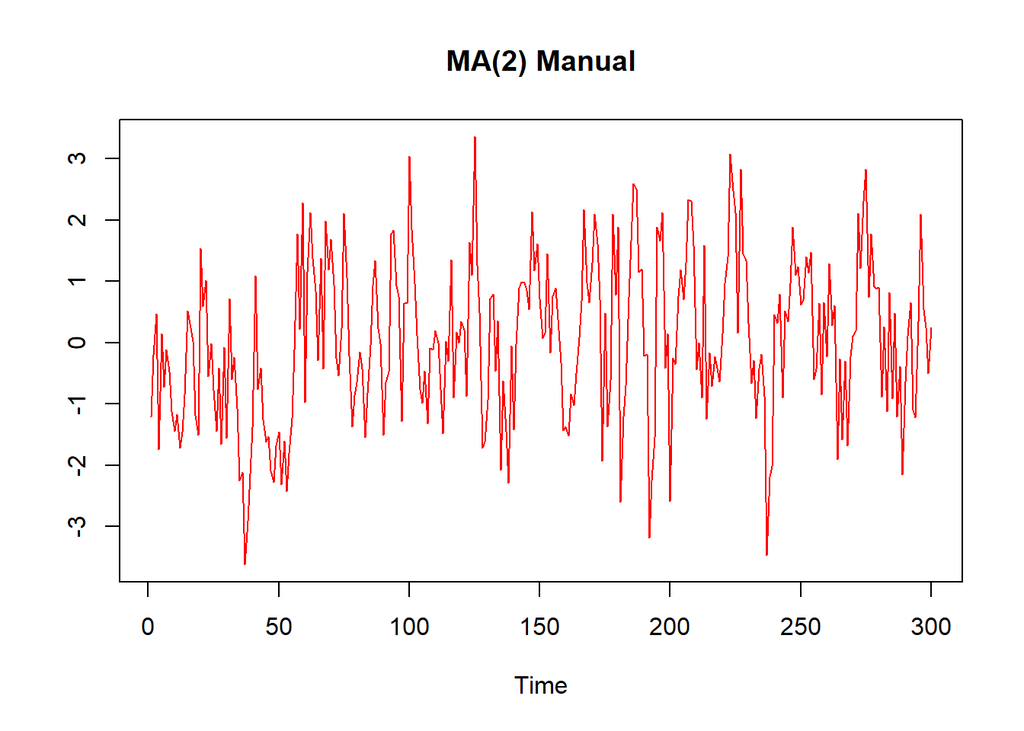

```r
ts.plot(ma2, main="MA(2) Manual", ylab="", col="red")
```

Berdasarkan plot time series, MA(2) stasioner dalam rataan

### ACF MA(2)

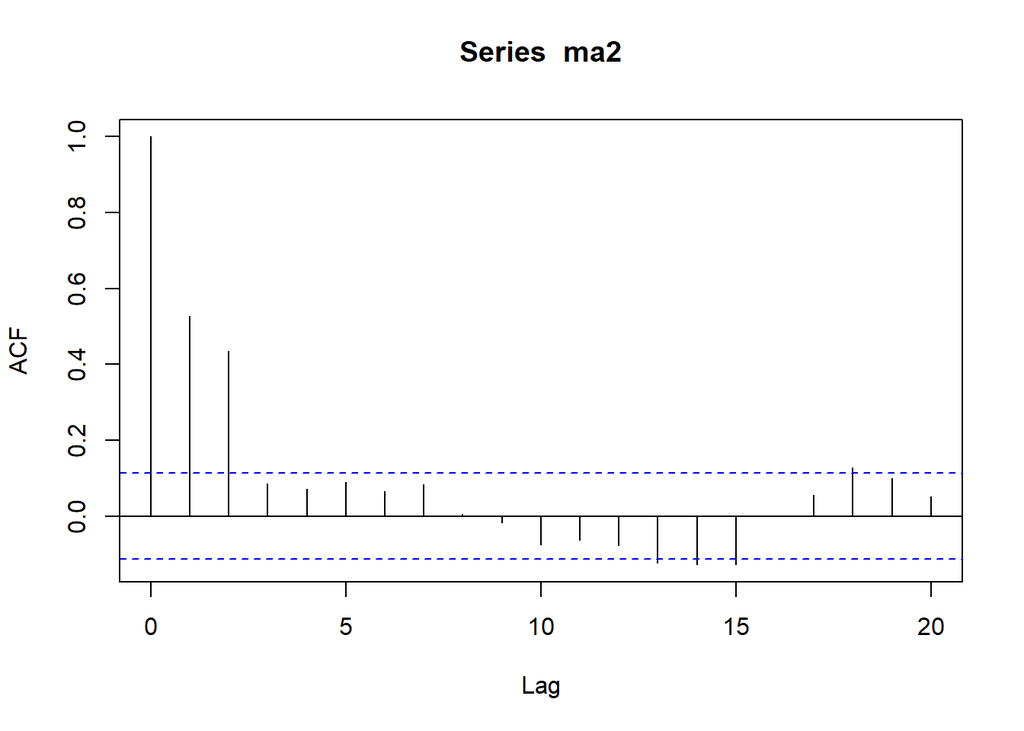

```r
acf(ma2,lag.max = 20)
```

Berdasarkan plot ACF, MA cuts off di lag 2

### PACF MA(2)

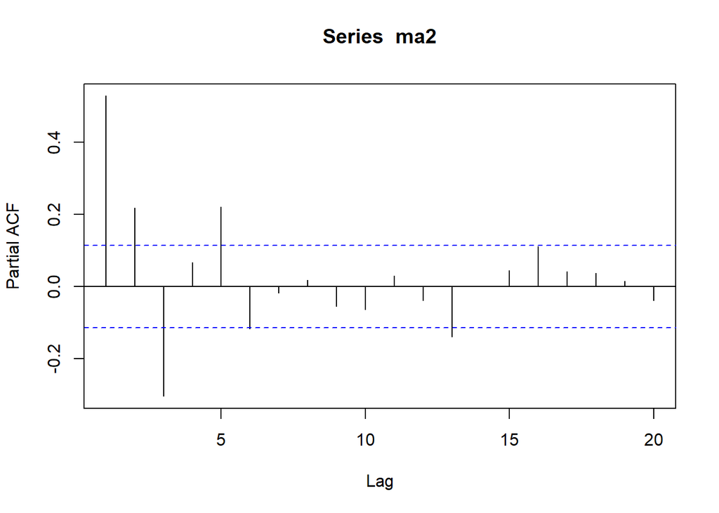

```r
pacf(ma2,lag.max = 20)
```

Berdasarkan plot PACF, PACF tails off dan membentuk gelombang cosinus

### EACF MA(2)

```r
TSA::eacf(ma2)
```

```
## AR/MA
##   0 1 2 3 4 5 6 7 8 9 10 11 12 13
## 0 x x o o o o o o o o o  o  x  x
## 1 x x x o o o o o o o o  o  o  o
## 2 x x x x o o o o o o o  o  o  o
## 3 x x x x x o o o o o o  o  o  o
## 4 x x x x x o o o o o o  o  o  o
## 5 x x o x x o x o o o o  o  o  o
## 6 x x x o x o o x o o o  o  o  o
## 7 x o x o x o o x o o o  o  o  o
```

Berdasarkan pola segitiga nol pada plot EACF, terlihat bahwa segitiga nol berada pada ordo AR(0) dan ordo MA(2)

###Scatterplot antar lag #### Yt dengan Yt-1

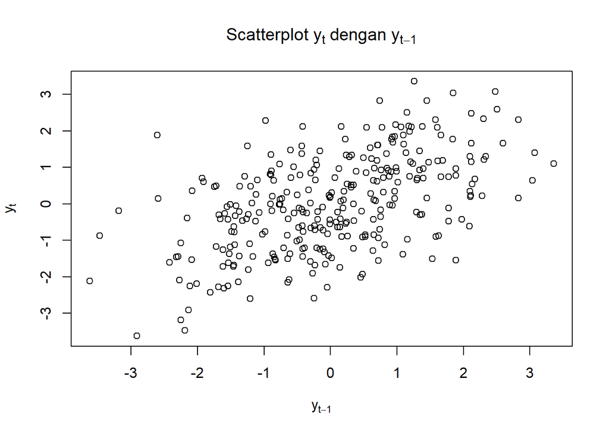

```r
plot(ma2[-1], ma2[-length(ma2)], xlab=expression(y[t-1]), ylab=expression(y[t]), main=expression("Scatterplot"~y[t]~"dengan"~y[t-1]))
```

#### Korelasi Yt dengan Yt-1

```r
cor(ma2[-1], ma2[-length(ma2)])
```

```
## [1] 0.5282201
```

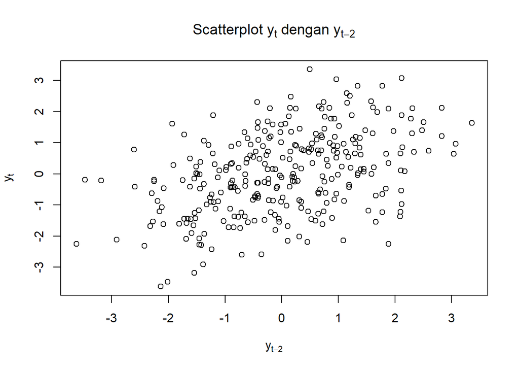

```r
plot(ma2[-c(1,2)], ma2[-c(length(ma2)-1,length(ma2))], xlab=expression(y[t-2]), ylab=expression(y[t]), main=expression("Scatterplot"~y[t]~"dengan"~y[t-2]))
```

#### Korelasi Yt dengan Yt-2

```r
cor(ma2[-c(1,2)], ma2[-c(length(ma2)-1,length(ma2))])
```

```
## [1] 0.4356204
```

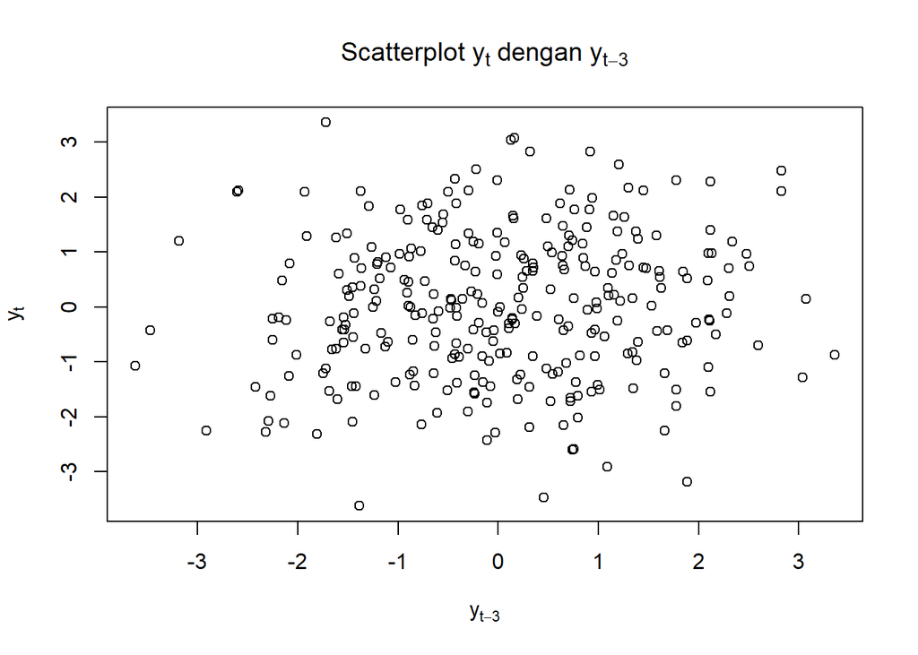

```r
plot(ma2[-c(1,2,3)], ma2[-c(length(ma2)-2,length(ma2)-1,length(ma2))], xlab=expression(y[t-3]), ylab=expression(y[t]), main=expression("Scatterplot"~y[t]~"dengan"~y[t-3]))
```

#### Korelasi Yt dengan Yt-3

```r
cor(ma2[-c(1,2,3)], ma2[-c(length(ma2)-2,length(ma2)-1,length(ma2))])
```

```
## [1] 0.08544546
```

### Autokorelasi

```r
acf(ma2, lag.max = 20, plot = FALSE)$acf
```

```
## , , 1
##
##                [,1]
##  [1,]  1.0000000000
##  [2,]  0.5274037998
##  [3,]  0.4348113776
##  [4,]  0.0852660511
##  [5,]  0.0714803136
##  [6,]  0.0896533470
##  [7,]  0.0651807177
##  [8,]  0.0847582970
##  [9,]  0.0056687580
## [10,] -0.0171715269
## [11,] -0.0755944520
## [12,] -0.0624737581
## [13,] -0.0770269694
## [14,] -0.1222030610
## [15,] -0.1272771260
## [16,] -0.1268693313
## [17,] -0.0005005895
## [18,]  0.0551619280
## [19,]  0.1269538841
## [20,]  0.0995601802
## [21,]  0.0518706546
```

# 2. Model AR

## Proses AR

Proses AR dapat dituliskan sebagai berikut:

$$y_{t} = c + e_t + \phi_{1}Y_{t-1} +
\phi_{2}Y_{t-2} + \dots + \phi_{q}Y_{t-q} = c+{e_t+\sum_{i=1}^p
\phi_iY_{t-i}}$$
Terlihat bahwa $Y_t$ berperan penting dalam pembangkitan proses AR.

### Pembangkitan AR(2)

Akan dicoba membangkitkan proses AR, yaitu AR(2) dengan $\phi1 = 0.5$ dan $\phi1 = 0.2$ sebanyak 300 observasi dan $c=0$.

```r
set.seed(1234)
```

Nilai-nilai selanjutnya dapat dicari melalui *loop*. Bentuk loop dapat dilihat dari rumus AR(2) yang hendak dibangkitkan:

$$Y_t = e_t+0.5Y_{t-1}+0.2Y_{t-2}$$
### AR Manual

```r
n = length(wn)
ar2 = rep(0, n)

ar2[1] <- wn[1]
ar2[2] <- wn[2] + 0.5 * ar2[1]

for (i in 3:n) {
  ar2[i] <- wn[i] + 0.5 * ar2[i-1] + 0.2 * ar2[i-2]
}

ar2
```

```
##   [1] -1.207065749 -0.326103633  0.679976211 -2.070930324 -0.470345231
##   [6] -0.143302788 -0.740460400 -0.945522614 -1.185305386 -1.671795045
##  [11] -1.550151299 -2.107821103 -2.140194706 -1.427202757 -0.182146261
##  [16] -0.486799176 -0.790838346 -1.403974425 -1.697326562  1.286377013
##  [21]  0.437811414 -0.014504787 -0.360237983  0.276569492 -0.627483098
##  [26] -1.706632561 -0.404057179 -1.567010825 -0.879455148 -1.689078340
##  [31]  0.081867346 -0.772475074 -1.079304105 -1.195405128 -2.442656854
##  [36] -2.628028715 -3.982585377 -3.857891624 -3.019756746 -2.747354238
##  [41] -0.528132203 -1.882179673 -1.902080911 -1.608099392 -2.178805954
##  [46] -2.379537173 -2.732847970 -3.094317305 -2.617556366 -2.424491601
##  [51] -3.541788331 -2.837868410 -3.236181496 -3.200626439 -2.409859042
##  [56] -1.281998990  0.524846169 -0.767330137  1.327213794 -0.647667678
##  [61]  0.598197384  2.718556227  1.444157201  0.596156266  0.579304817
##  [66]  2.185968110  0.070237282  1.840139442  2.263681968  1.836341670
##  [71]  1.377800067  0.600699629  0.209385895  0.873119441  2.548707761
```

[output cut: 45 more lines]

### Arima.Sim

```r
ar3 = arima.sim(
  model = list(order = c(2,0,0), ar = c(0.5, 0.2)),
  n = 300
)
ar3
```

```
## Time Series:
## Start = 1
## End = 300
## Frequency = 1
##   [1] -1.7066325607 -0.4040571790 -1.5670108246 -0.8794551485 -1.6890783403
##   [6]  0.0818673463 -0.7724750738 -1.0793041051 -1.1954051279 -2.4426568541
##  [11] -2.6280287147 -3.9825853771 -3.8578916236 -3.0197567460 -2.7473542381
##  [16] -0.5281322030 -1.8821796728 -1.9020809107 -1.6080993919 -2.1788059544
##  [21] -2.3795371734 -2.7328479702 -3.0943173054 -2.6175563658 -2.4244916012
##  [26] -3.5417883306 -2.8378684102 -3.2361814957 -3.2006264394 -2.4098590424
##  [31] -1.2819989901  0.5248461693 -0.7673301373  1.3272137941 -0.6476676781
##  [36]  0.5981973841  2.7185562271  1.4441572006  0.5961562661  0.5793048174
##  [41]  2.1859681101  0.0702372818  1.8401394423  2.2636819683  1.8363416698
##  [46]  1.3778000670  0.6006996293  0.2093858952  0.8731194410  2.5487077608
##  [51]  1.2955793561 -0.2331697165 -0.5810507641 -0.0788975632 -0.4727180494
```

[output cut: 49 more lines]

### Plot AR(2)

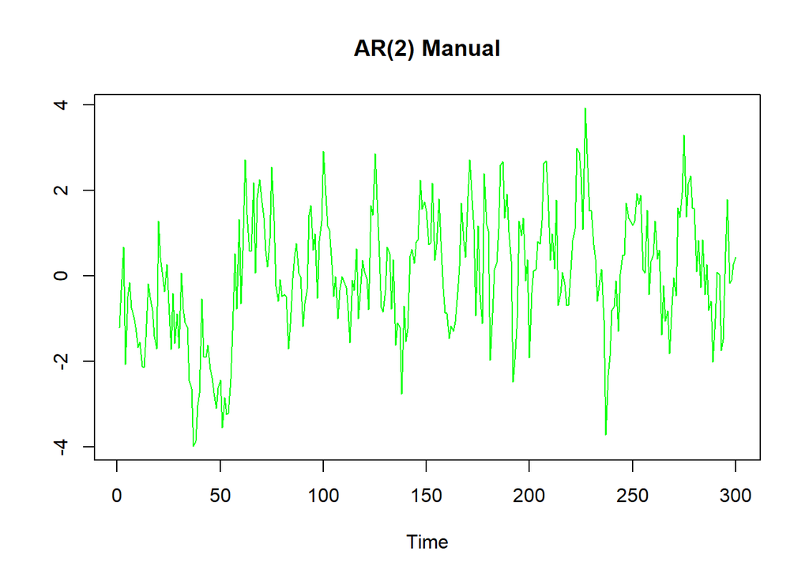

```r
ts.plot(ar2, main="AR(2) Manual", ylab="", col="green")
```

Dari plot terlihat data stasioner dalam rataan

### ACF AR(2)

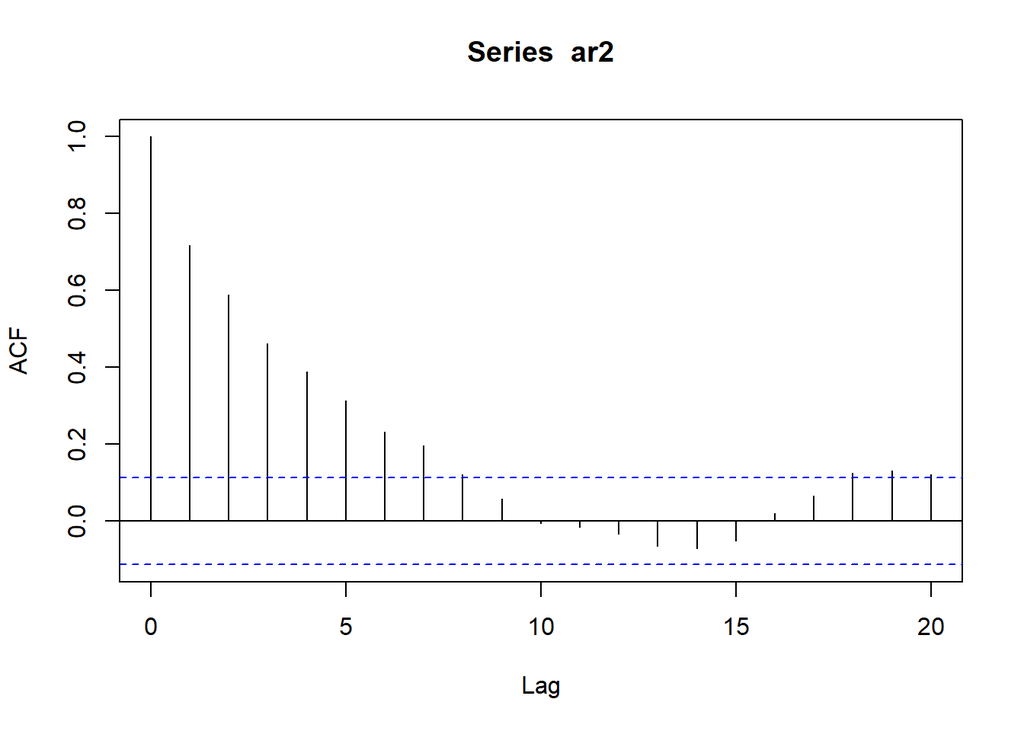

```r
acf(ar2, lag.max = 20)
```

Berdasarkan plot ACF, ACF tails off

### PACF AR(2)

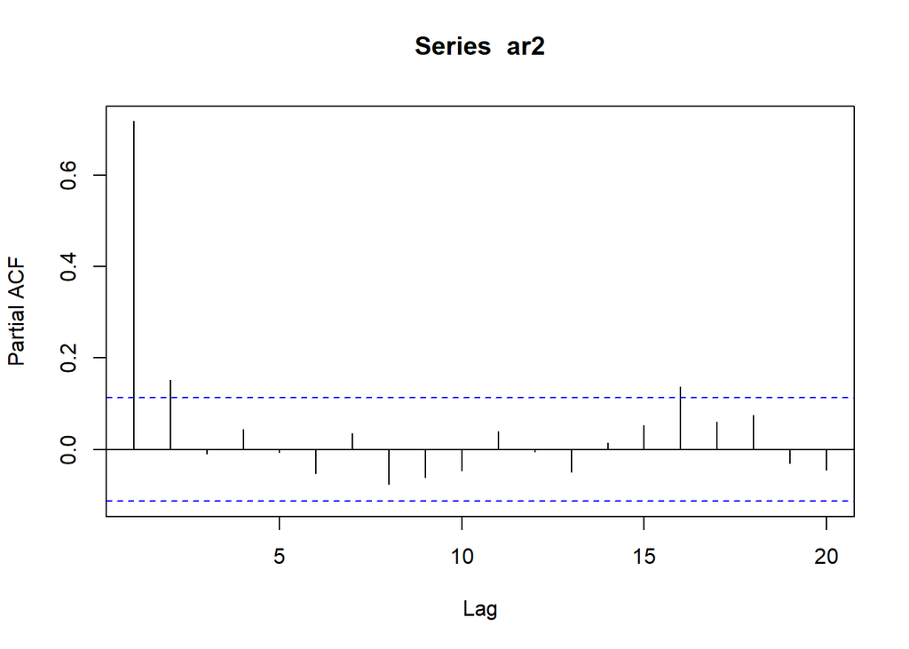

```r
pacf(ar2, lag.max = 20)
```

Berdasarkan plot PACF, PACF cuts off di lag 2

### EACF AR(2)

```r
TSA::eacf(ar2)
```

```
## AR/MA
##   0 1 2 3 4 5 6 7 8 9 10 11 12 13
## 0 x x x x x x x x o o o  o  o  o
## 1 x o o o o o o o o o o  o  o  o
## 2 o o o o o o o o o o o  o  o  o
## 3 x x o o o o o o o o o  o  o  o
## 4 x x o o o o o o o o o  o  o  o
## 5 o x o x o o x o o o o  o  o  o
## 6 x x x x o o o o o o o  o  o  o
## 7 x x x o x x o o o o o  o  o  o
```

Berdasarkan pola segitiga nol pada plot EACF, terlihat bahwa segitiga nol berada pada ordo AR(2) dan ordo MA(0)

### Scatterplot antar lag

#### Yt dengan Yt-1

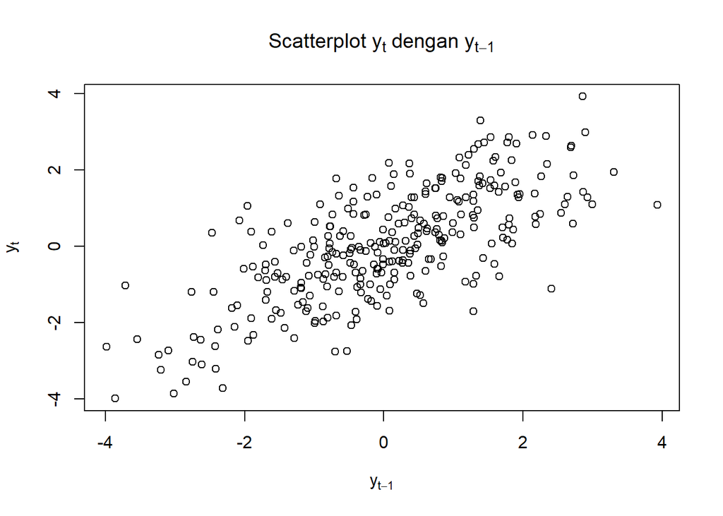

```r
plot(ar2[-1], ar2[-length(ar2)], xlab=expression(y[t-1]), ylab=expression(y[t]), main=expression("Scatterplot"~y[t]~"dengan"~y[t-1]))
```

#### Korelasi Yt dengan Yt-1

```r
cor(ar2[-1], ar2[-length(ar2)])
```

```
## [1] 0.7181941
```

Korelasi Yt dengan Yt-1 sebesar 0.7181 mendekati perhitungan manual sebesar $\rho_1=\phi^1=0.625$

#### Yt dengan Yt-2

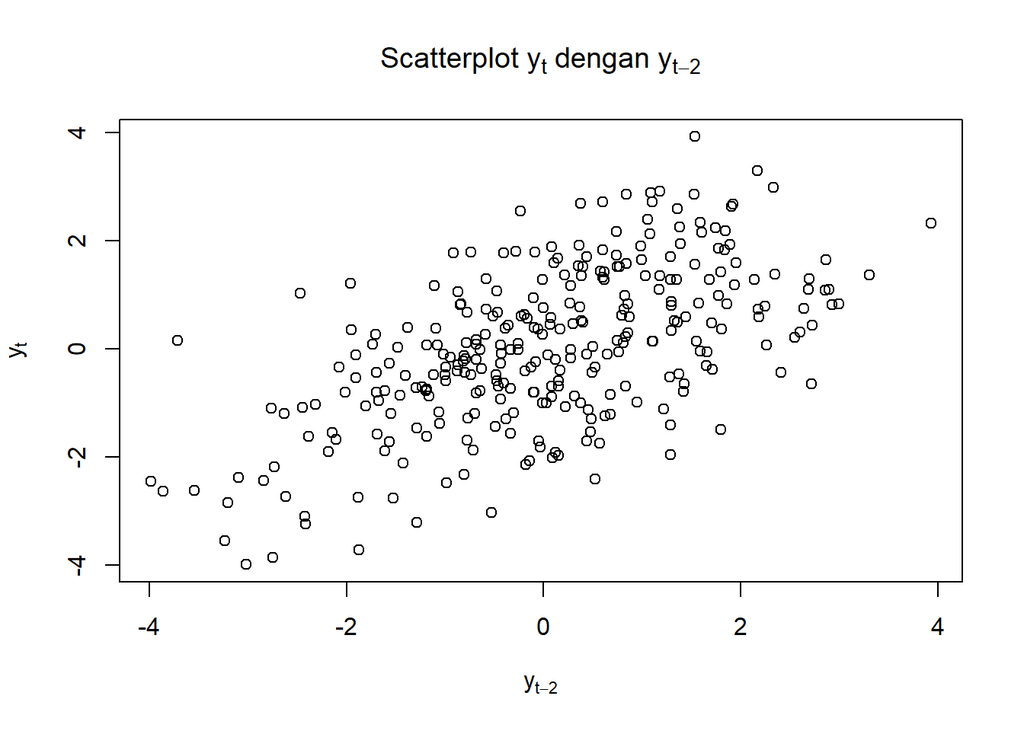

```r
plot(ar2[-c(1,2)], ar2[-c(length(ar2)-1,length(ar2))], xlab=expression(y[t-2]), ylab=expression(y[t]), main=expression("Scatterplot"~y[t]~"dengan"~y[t-2]))
```

#### Korelasi Yt dengan Yt-2

```r
cor(ar2[-c(1,2)], ar2[-c(length(ar2)-1,length(ar2))])
```

```
## [1] 0.5889847
```

#### Yt dengan Yt-3

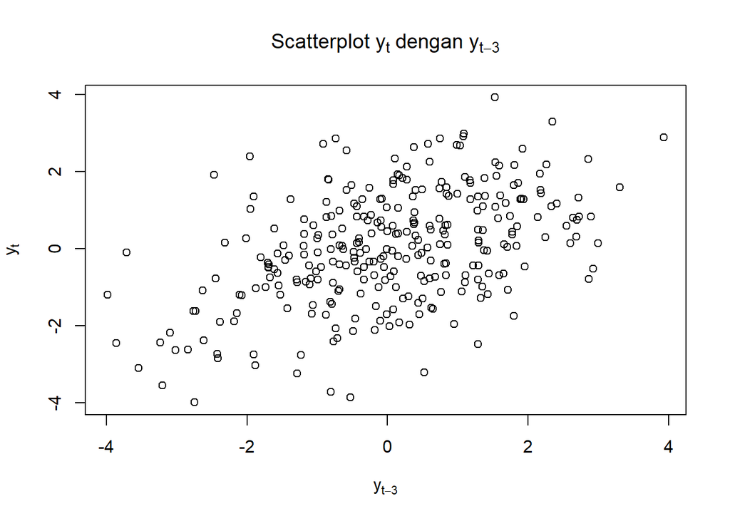

```r
plot(ar2[-c(1,2,3)], ar2[-c(length(ar2)-2,length(ar2)-1,length(ar2))], xlab=expression(y[t-3]), ylab=expression(y[t]), main=expression("Scatterplot"~y[t]~"dengan"~y[t-3]))
```

#### Korelasi Yt dengan Yt-3

```r
cor(ar2[-c(1,2,3)], ar2[-c(length(ar2)-2,length(ar2)-1,length(ar2))])
```

```
## [1] 0.4630342
```

Korelasi Yt dengan Yt-3 sebesar 0.4630 mendekati perhitungan manual sebesar $\rho_3=\phi^3=0.38125$ ### Autokorelasi

```r
acf(ar2, lag.max = 20, plot = FALSE)$acf
```

```
## , , 1
##
##              [,1]
##  [1,]  1.00000000
##  [2,]  0.71720653
##  [3,]  0.58808017
##  [4,]  0.46216936
##  [5,]  0.38859215
##  [6,]  0.31389193
##  [7,]  0.23281161
##  [8,]  0.19577033
##  [9,]  0.12080543
## [10,]  0.05682403
## [11,] -0.00505709
## [12,] -0.01549188
## [13,] -0.03305083
## [14,] -0.06602588
## [15,] -0.07056080
## [16,] -0.05159213
## [17,]  0.02081824
## [18,]  0.06497986
## [19,]  0.12413129
## [20,]  0.13132270
## [21,]  0.12177362
```

# 3. Model ARMA

## Proses ARMA

$$y_{t} = c + \sum_{i=1}^p \phi_{i}y_{t-i} + \sum_{j=1}^q e_{t-j}+ e_{t}$$

### Pembangkitan ARMA(2,2)

```r
set.seed(1234)
n = 300
wn = rnorm(n)
arma_data = rep(0, n)
arma_data[1:2] = wn[1:2]
for(i in 3:n){
  arma_data[i] = 0.5*arma_data[i-1] + 0.2*arma_data[i-2] + wn[i] + 0.4*wn[i-1] + 0.6*wn[i-2]
}
arma_data
```

```
##   [1] -1.20706575  0.27742924  0.36847490 -1.50574039 -0.53766490 -1.29969338
##   [7] -0.87222246 -1.16894421 -1.88686532 -2.62101924 -2.85976172 -3.67737093
##  [13] -3.87256190 -3.51682974 -2.01340200 -1.39787953 -1.08104743 -2.00187014
##  [19] -2.72540011 -0.22882482 -0.06137315  0.93599896 -0.10064445  0.12583632
##  [25] -0.73142392 -1.79048404 -1.46228520 -2.75191579 -1.74816209 -2.98066156
##  [31] -1.12112807 -1.75293957 -1.33899414 -2.09047491 -3.56829700 -4.32225497
##  [37] -6.49933032 -7.02769676 -6.95242937 -6.26996504 -3.43890746 -3.74182948
##  [43] -2.97182019 -3.49823048 -3.96328734 -4.21591391 -4.99194239 -5.61517573
##  [49] -5.49498973 -5.32810275 -6.08211743 -5.70927767 -6.49640107 -6.19781948
##  [55] -5.63181806 -4.16631812 -1.43386859 -1.32659086  1.33518960 -0.57718012
##  [61]  1.13545868  2.56923464  2.89049817  2.80495292  1.68426167  2.77538382
##  [67]  1.29220743  3.17981523  3.04188012  3.84589813  3.47054592  2.25362466
##  [73]  1.27634579  1.31729358  3.02358708  2.83893413  1.81428668  0.10302896
##  [79] -0.45121970 -0.85290753 -0.66635425 -0.93510416 -2.14779642 -2.08562341
##  [85] -1.51503473 -0.24121274  0.91556687  0.64537308  0.48311177 -1.14217407
```

[output cut: 35 more lines]

### Arima.Sim

```r
arma2 = arima.sim(
  model = list(order = c(2,0,2), ar = c(0.5, 0.2), ma = c(0.4, 0.6)),
  n = 300
)
arma2
```

```
## Time Series:
## Start = 1
## End = 300
## Frequency = 1
##   [1] -2.0296272586  0.1804874357 -1.0857429326  0.2019685297  0.5101006237
##   [6]  0.3116647978  1.1440157679  0.4568971792 -0.3804875233 -0.8758133113
##  [11]  0.3166261152  0.2548874061  0.2592079202 -0.3290331722 -0.2948120396
##  [16]  0.8417548499  2.0860897066  2.3426969416  3.4797265438  1.9702862497
##  [21] -0.2703838028 -1.6091794075 -2.9699033669 -4.6121759676 -3.5735246545
##  [26] -4.6576056483 -3.2455887429 -4.7021051669 -3.2231197169 -1.3940059863
##  [31] -1.1346987187 -0.1752041013  1.0623014400  2.1418761113  4.7392121372
##  [36]  4.1182608009  4.0004548088  2.2502034531  3.0645576995  0.9645314951
##  [41]  1.7489003118  0.3724604884  2.9537132225  1.8162605804  1.0974763535
##  [46]  0.1760865572 -0.5446303408 -0.9525033432 -0.8123258962 -1.3227469686
##  [51] -1.5334325506 -0.9672480418 -1.3288936550 -2.5250400524 -5.1130294931
```

[output cut: 49 more lines]

### Plot ARMA(2,2)

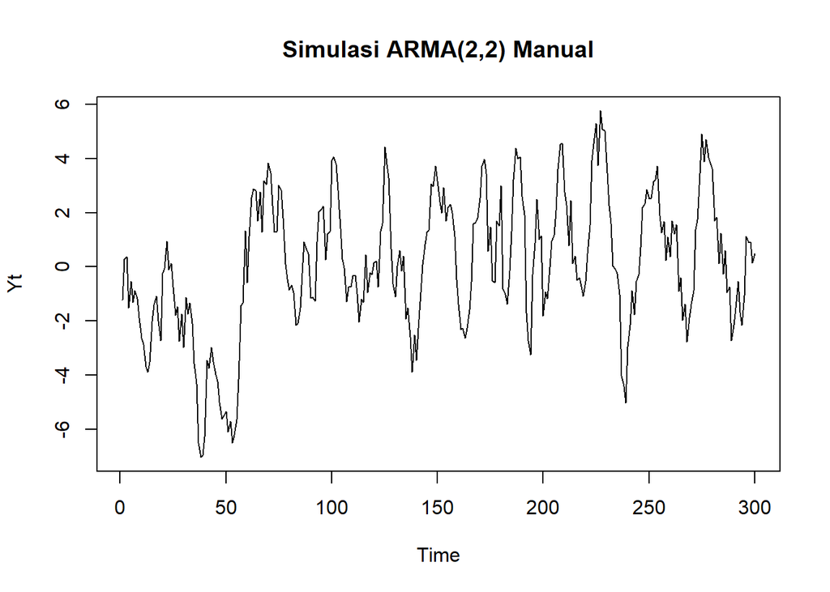

```r
ts.plot(arma_data, main="Simulasi ARMA(2,2) Manual", ylab="Yt")
```

### Plot ARMA Arima.Sim

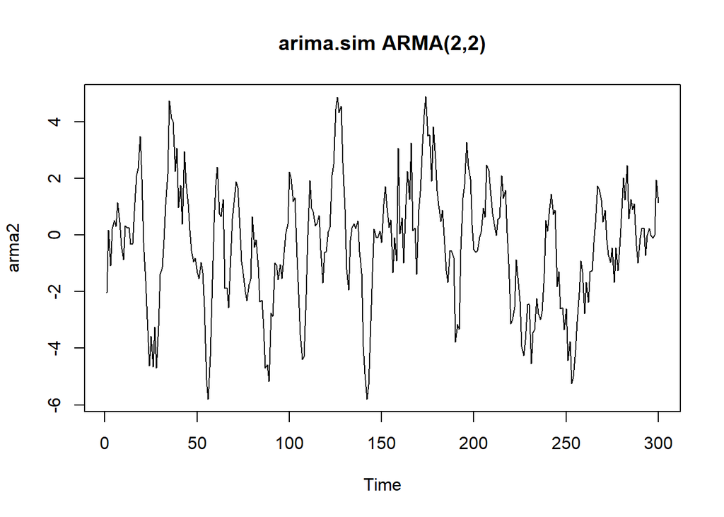

```r
ts.plot(arma2, main = "arima.sim ARMA(2,2)")
```

### ACF ARMA(2,2)

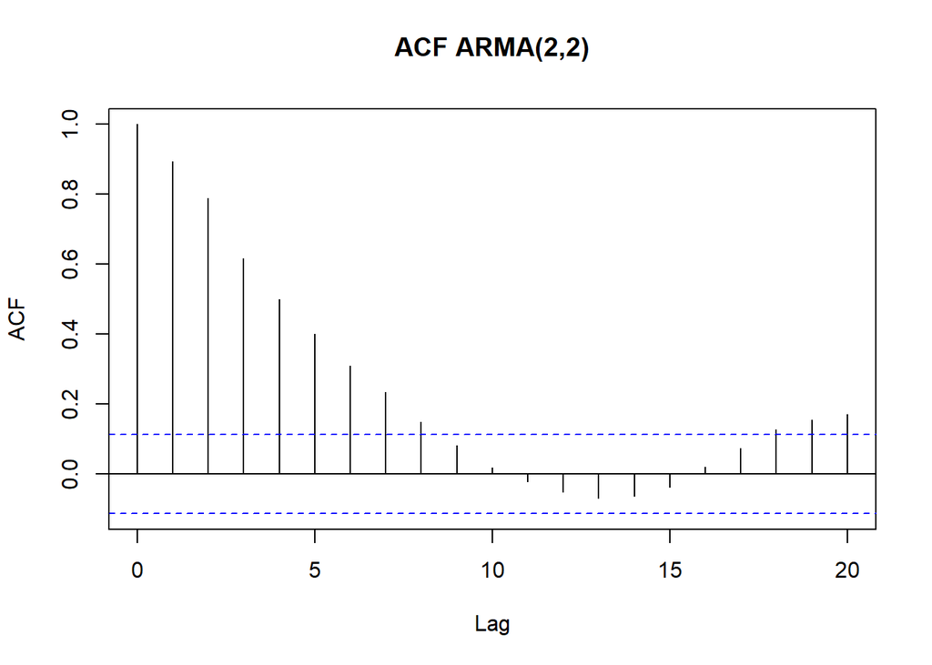

```r
acf(arma_data, lag.max = 20, main="ACF ARMA(2,2)")
```

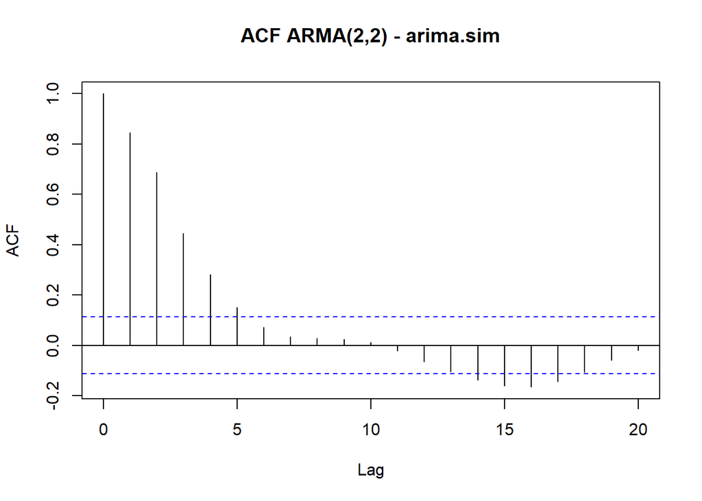

```r
acf(arma2, lag.max = 20, main="ACF ARMA(2,2) - arima.sim")
```

Berdasarkan plot ACF, ACF tails off

### PACF ARMA(2,2)

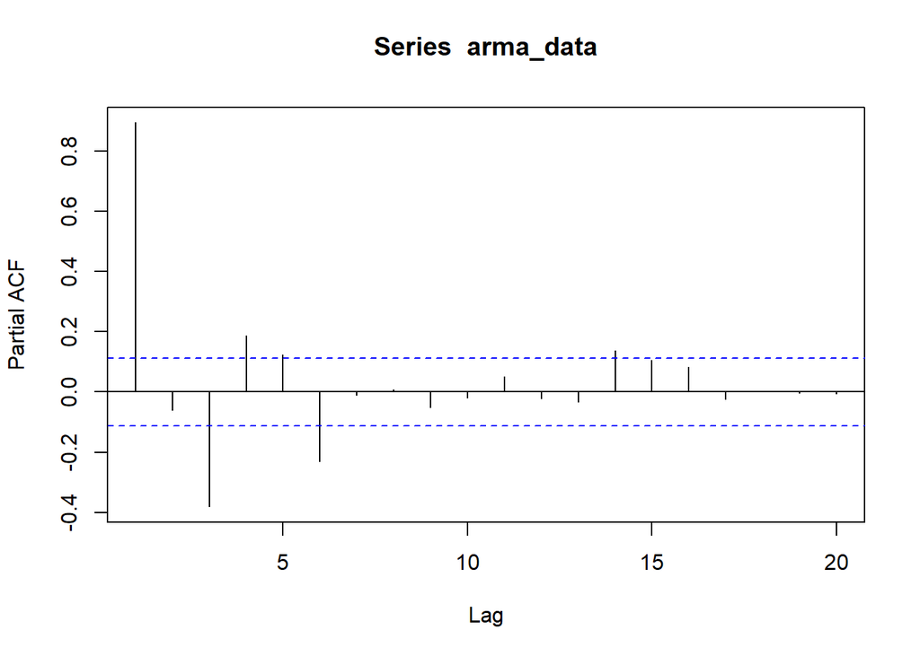

```r
pacf(arma_data, lag.max = 20)
```

### PACF Arima.Sim

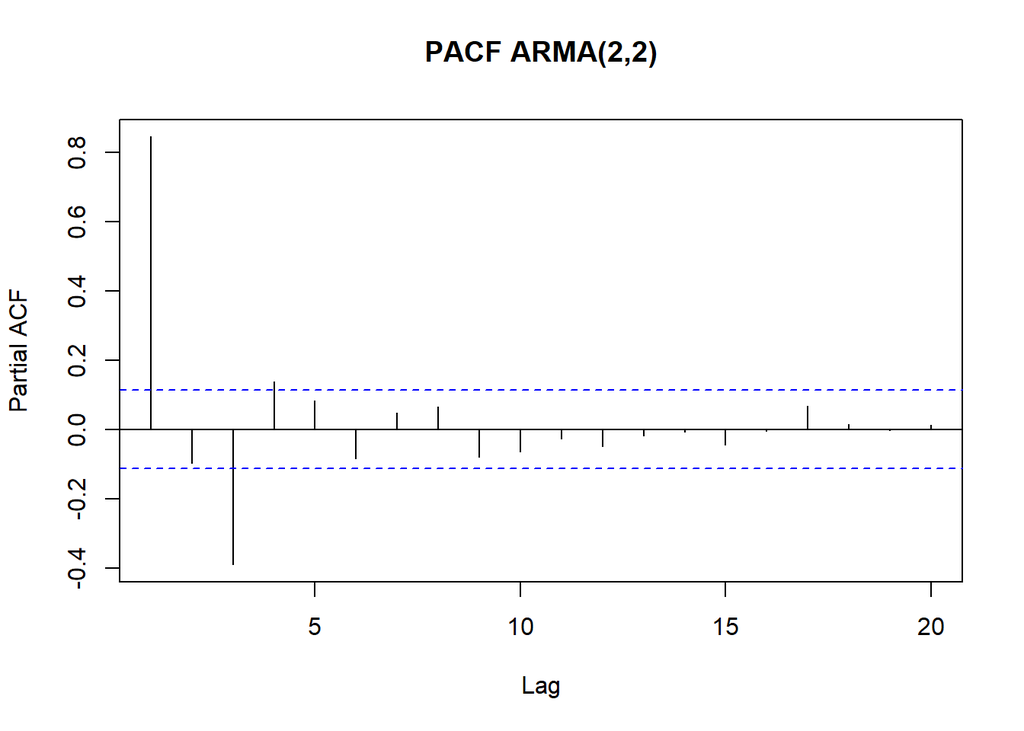

```r
pacf(arma2, lag.max = 20, main="PACF ARMA(2,2)")
```

### EACF ARMA(2,2)

```r
TSA::eacf(arma_data)
```

```
## AR/MA
##   0 1 2 3 4 5 6 7 8 9 10 11 12 13
## 0 x x x x x x x x o o o  o  o  o
## 1 o x o o o o x o o o o  o  o  o
## 2 x x o o o o x o o o o  o  o  o
## 3 x x o x o o x o o o o  o  o  o
## 4 x x x x o o x o o o o  o  o  o
## 5 x x x x x x x o o o o  o  o  o
## 6 o o x o x x o o o o o  o  o  o
## 7 o o x o x x o x o o o  o  o  o
```

### EACF ARMA(2,2) Arima.Sim

```r
TSA::eacf(arma2)
```

```
## AR/MA
##   0 1 2 3 4 5 6 7 8 9 10 11 12 13
## 0 x x x x x o o o o o o  o  o  x
## 1 x x o o o o o o o o o  o  o  o
## 2 x x x x o o o o o o o  o  o  o
## 3 x x o x o o o o o o o  o  o  o
## 4 x x o x x o o o o o o  o  o  o
## 5 x x x x o o o o o o o  o  o  o
## 6 x x x x o x o o o o o  o  o  o
## 7 x x o x x x x o o o o  o  o  o
```

### Scatterplot Antar Lag

#### Yt dengan Yt-1

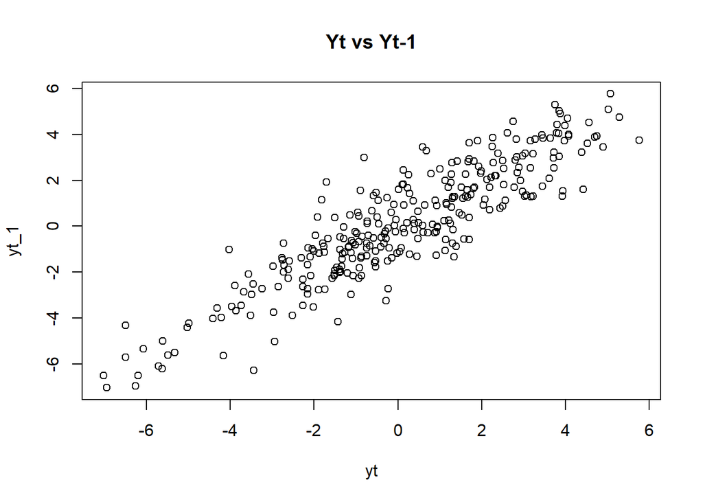

```r
yt = arma_data[-1]
yt_1 = arma_data[-n]
plot(x = yt, y = yt_1, main="Yt vs Yt-1")
```

#### Korelasi

```r
cor(yt, yt_1)
```

```
## [1] 0.8946787
```

#### Yt dengan Yt-2

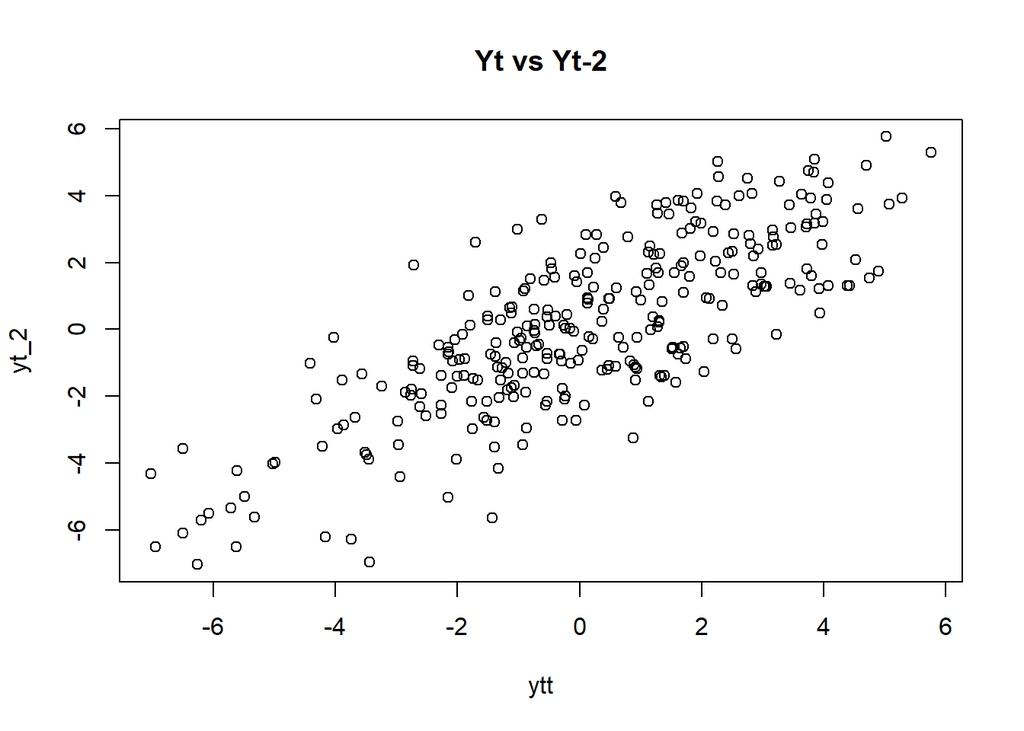

```r
ytt = arma_data[-c(1,2)]
yt_2 = arma_data[-c(n-1,n)]
plot(x = ytt, y = yt_2, main="Yt vs Yt-2")
```

#### Korelasi

```r
cor(ytt, yt_2)
```

```
## [1] 0.78822
```

Korelasi antara Yt dengan Yt-2 = 0.7882, mendekati perhitungan manual sebesar $\rho_2=0.7492$

#### Yt dengan Yt-3

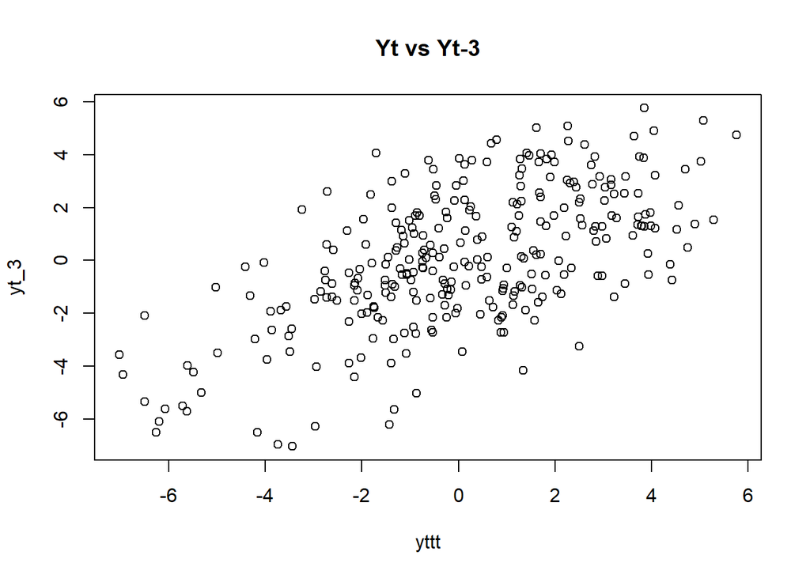

```r
yttt = arma_data[-c(1,2,3)]
yt_3 = arma_data[-c(n-2,n-1,n)]
plot(x = yttt, y = yt_3, main="Yt vs Yt-3")
```

#### Korelasi

```r
cor(yttt, yt_3)
```

```
## [1] 0.6177423
```

Korelasi antara Yt dengan Yt-3 = 0.6177, mendekati perhitungan manual sebesar $\rho_3=0.5464$ ### Autokorelasi

```r
acf(arma_data, lag.max = 20, plot = FALSE)$acf
```

```
## , , 1
##
##              [,1]
##  [1,]  1.00000000
##  [2,]  0.89425596
##  [3,]  0.78783999
##  [4,]  0.61732077
##  [5,]  0.49993844
##  [6,]  0.40089929
##  [7,]  0.31016176
##  [8,]  0.23367252
##  [9,]  0.14898757
## [10,]  0.08067289
## [11,]  0.01773312
## [12,] -0.02137787
## [13,] -0.05052341
## [14,] -0.06860604
## [15,] -0.06301916
## [16,] -0.03786645
## [17,]  0.02046040
## [18,]  0.07393272
## [19,]  0.12646017
## [20,]  0.15375318
## [21,]  0.17070466
```